# Bob Ross -Joy of Painting-

Jonathan Bouchet

2017-06-14

This vignette is based on [538 study : A statistical analysis of the work of Bob Ross](https://fivethirtyeight.com/features/a-statistical-analysis-of-the-work-of-bob-ross/). Bob Ross was an american painter and host of the *The Joy of Painting*, an instructional television program that aired from 1983 to 1994 on PBS in the United States.

Load required packages to reproduce analysis as well as the dataset.

```r
library(ggplot2)
library(dplyr)
library(fivethirtyeight)
library(ggthemes)
library(knitr)
library(corrplot)
library(ggraph)
library(igraph)
library(plyr)
```

## Data explanation and cleaning

The author of the article (W. Hickey) went through all Bob Ross’s paintings and coded the describing elements (trees, water, mountain, etc …) : when an element is present in a painting, it is encoding by 1 in the relevant column. He wasn’t able to analyze 3 paintings. There are also 2 episodes having the same title, so one of them is renamed to avoid errors during a group_by episode. In addition, there are 22 episodes where Bob Ross did not paint.

```r
df <- bob_ross
#define incomplete paintings
incomplete <-c("PURPLE MOUNTAIN RANGE","COUNTRY CHARM","PEACEFUL REFLECTIONS")
df <- df %>% filter(guest==0 & !(title %in% incomplete))
#check the 2 episodes with same name
#df %>% filter(title=="LAKESIDE CABIN")
df[df$episode=='S08E02','title']<-'LAKESIDE CABIN 2'
```

Given the structure of the dataframe :

## Study by Features

- a `colSum` can provide the total number and percentage (`tot`, `featurePercentage`) of features through all the paintings as well as their frequency(`featureFreq`).
- a `rowSum` can provide the distribution of features present per painting.

## Frequency

```r
#calculate the colSums for numeric columns and transpose the result
temp <- as.data.frame(df %>%
                        select(-episode, -season, -episode_num ,-title) %>%
                        summarise_each(funs(sum)) %>% t())

#rename,switch columns and calculate percentage over all paintings and frequency though all episodes
per_features <- temp %>% tibble::rownames_to_column() %>%
  select(feature=rowname, tot = V1) %>%
  mutate(
    feature_percentage = (tot / sum(tot))*100,
    feature_percentage_Label = paste0(round(feature_percentage,1),"%"),
    feature_freq = tot/ nrow(df)*100,
    feature_freq_label = paste0(round(feature_freq,1),"%"))
```

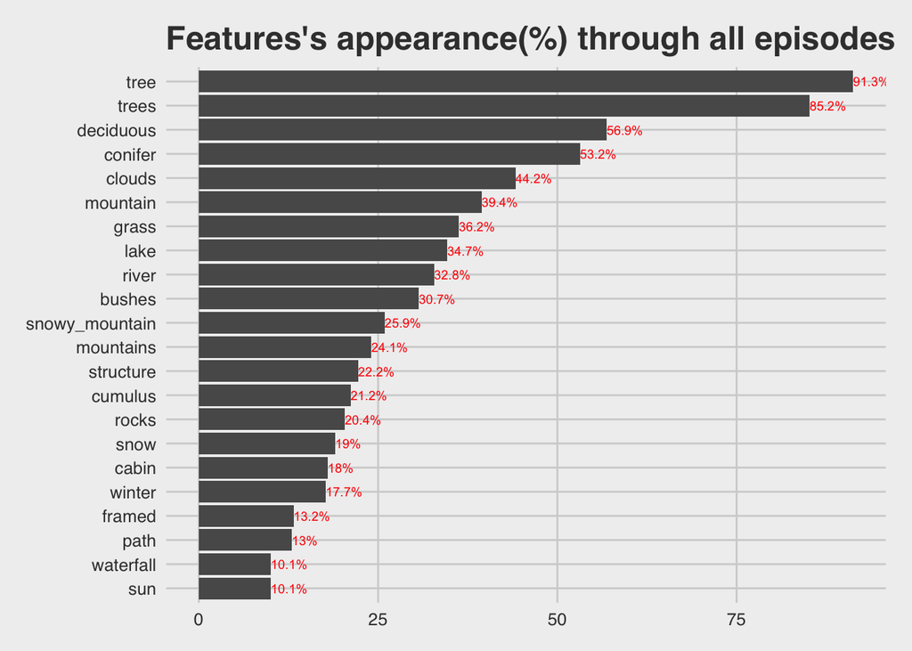

```r
feature_freq_cut <- 10 #10% most present features
ggplot(data=filter(per_features,feature_freq>feature_freq_cut), aes(x=reorder(feature,feature_freq),y=feature_freq)) +
  geom_bar(stat='identity') + geom_text(aes(label=feature_freq_label), position=position_dodge(width=0.9), vjust=.5,hjust=0,size=2.5,color='red') +
  coord_flip() + theme_fivethirtyeight() + ggtitle('Features\'s appearance(%) through all episodes')
```

## Correlation

Since a row with no entries causes a standard deviation = 0, features are selected based on their number.

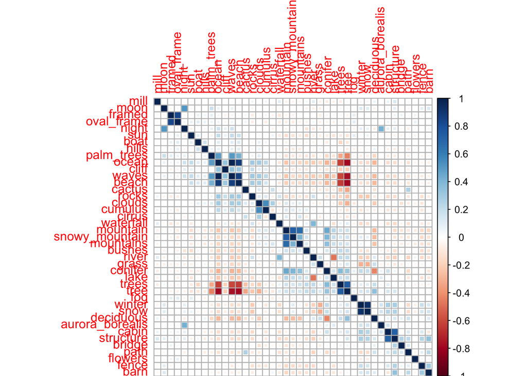

```r
#find features present
top<-c(per_features %>% filter(tot>1) %>% arrange(-tot) %>% select(feature))
num_data<-df %>% select_(.dots = top$feature)
num_cols <- sapply(num_data, is.numeric)
corrplot(cor(num_data[,num_cols]), method='square',order="AOE")
```

- we see positive correlation for the expected cases, like `tree` / `trees`, or `night` / `moon`
- we also see negative correlation for features totally different, such as `waves` / `tree`
- a negative correlation means that as one of the variables increases, the other tends to decrease, and vice versa, so it makes sense to find an anti-correlation in the case `waves` / `tree` for example.

## Study by Episodes

### Episodes having the greatest number of features

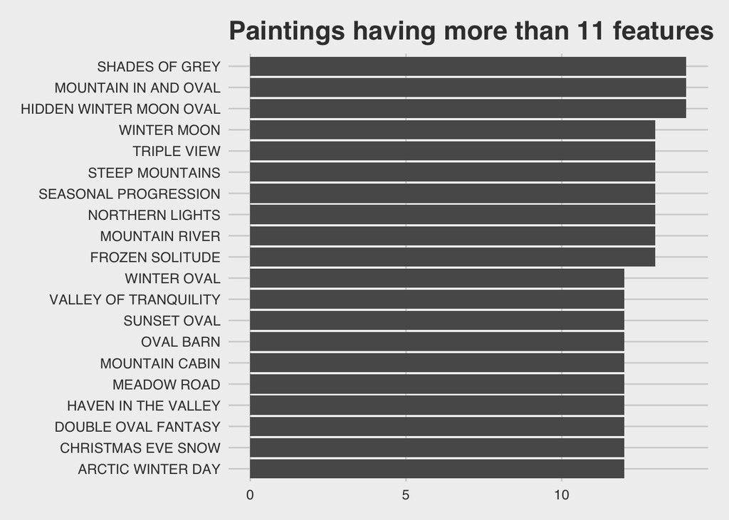

```r
per_episode <- df %>%
  select(-episode,-season,-episode_num ,-title) %>%
  select_if(is.numeric) %>%
  summarise(sum = rowSums(.)) %>%
  cbind(episode = df$title) %>% arrange(-sum)

#select a cut
cut_features<-11
ggplot(data=filter(per_episode,sum>cut_features), aes(x=reorder(episode,sum),y=sum)) +
  geom_bar(stat='identity') +
  coord_flip() + theme_fivethirtyeight() +
  ggtitle(paste0('Paintings having more than ', cut_features,' features'))
```

### Episodes distribution vs. their number of features

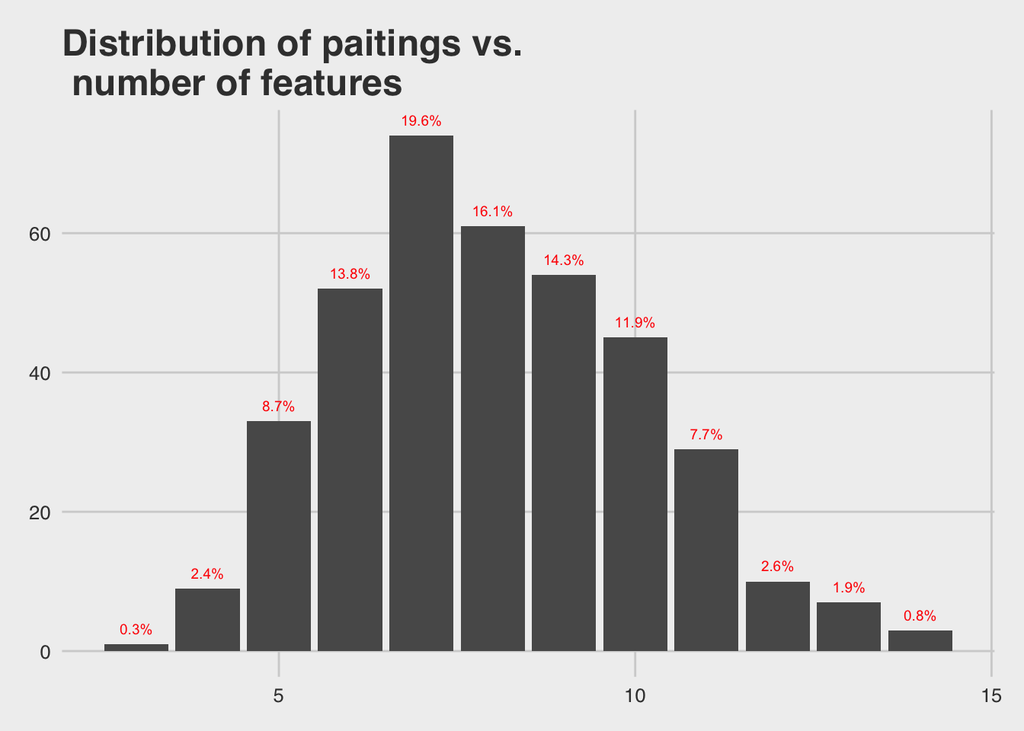

```r
per_episode_summary <- per_episode %>%
  group_by(sum) %>%
  dplyr::summarise(tot_features=n()) %>%
  mutate(
    percent = (tot_features/ sum(tot_features))*100,
    label = paste0(round(percent,1),"%"))

ggplot(data=per_episode_summary, aes(x=sum,y=tot_features)) +
  geom_bar(stat='identity') +
  geom_text(aes(label=label), position=position_dodge(width=0.9), vjust=-1,hjust=.5,size=2.5,color='red')+
  theme_fivethirtyeight() + ggtitle('Distribution of paitings vs. \n number of features')
```

- the mean number of features among all paintings is:

```r
mean(per_episode$sum)
```

```
## [1] 8.015873
```

## Network analysis

### Motivation

To further study the features’s correlation, a network analysis can be performed. In this case, for each painting an object `feature_i, feature_j` is built where i,j are indexes for a given painting. The `ggraph` package takes as input a dataframe with 2 columns and makes a graph network based on these 2 columns. The function below loops over all features in a given painting and make the graph connections.

```r
#function to loop an array of X features and return a DF with feature_1 | feature_2
make_connection<-function(x){
    feature_1<-c()
    feature_2<-c()
    cnt<-1
    for(i in 1:(nrow(x)-1)){
        for(j in (i+1):(nrow(x))){
            feature_1[cnt]<-(x[i,1])
            feature_2[cnt]<-(x[j,1])
            cnt<-cnt+1
            }
    }
    res<-data.frame("feature_1"=feature_1,"feature_2"=feature_2)
    return(res)
}
```

### Result with all paintings for the first season

```r
#create empty DF to store the results
season_1 <- df %>% filter(season==1)

#empty dataframe to save all the connections
season1_res <- data.frame("feature_1"= character(),"feature_2"=character())

#loop over paintings in season 1
for(i in 1:nrow(season_1)){
    #select features of ith painting and make a dataframe
    temp <- as.data.frame(season_1 %>% select(-episode, -season, -episode_num ,-title) %>% dplyr::slice(i) %>% t())
    pos_data <- temp %>% tibble::rownames_to_column() %>% select(feature=rowname, number = V1) %>% filter(number>0)
    res<-make_connection(pos_data)
    season1_res<-rbind(season1_res,res)
}
```

The interesting thing is that we can apply some weights to the graph. The weights are based on the frequency of the connection between 2 features.

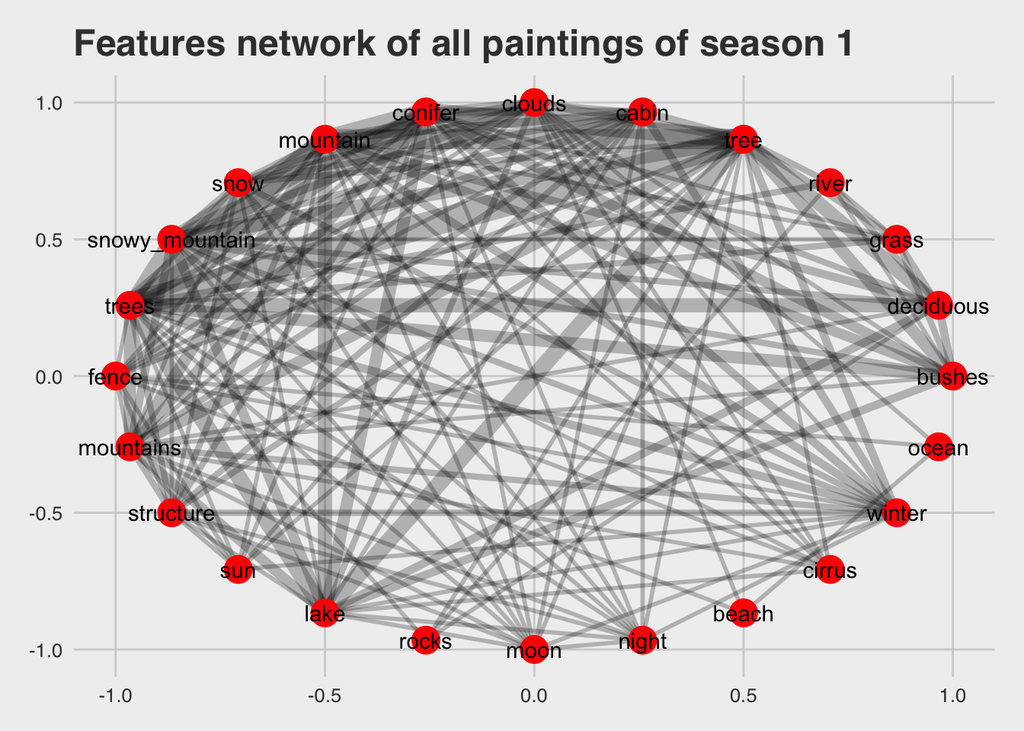

```r
graph_s1<-plyr::count(season1_res, vars = c("feature_1","feature_2"))
colnames(graph_s1)[3]<-'weight'

g1<-graph.data.frame(graph_s1)
ggraph(g1,layout='circle') +
  geom_edge_fan(aes(width=E(g1)$weight),alpha=.25,show.legend = FALSE) +
  geom_node_point(size=6,color="red",alpha=1) +
  geom_node_text(aes(label = name)) + theme_fivethirtyeight() + ggtitle('Features network of all paintings of season 1')
```

- larger width indicate the frequency of this correlation
- the most frequent conenction are `tree | trees`, `tree | lake`, `lake | mountain`, which makes sense as seen with the correlation plot.